# Lecture 17: Distributions

Associated Textbook Sections: [10.1, 10.2, 10.3, and 10.4](https://ccsf-math-108.github.io/textbook/chapters/10/1/Empirical_Distributions.html)

## Outline

- Distributions
- Law of Large Numbers
- A Statistic

## Set Up the Notebook

```python
from datascience import *
import numpy as np
%matplotlib inline
import matplotlib.pyplot as plt
plt.style.use('fivethirtyeight')
```

## Distributions

### Probability Distribution

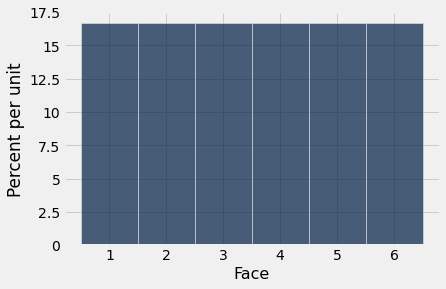

- Random quantity with various possible values
- Probability Distribution:
  - All the possible values of the quantity
  - The probability of each of those values
- If you can do the math, you can work out the probability distribution without ever simulating it
- But... simulation is often easier!

### Empirical Distribution

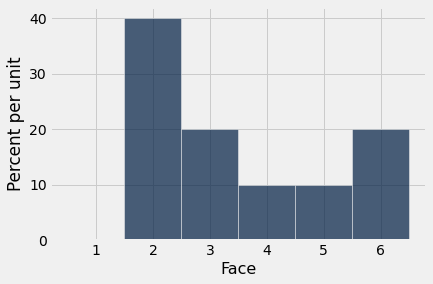

- Empirical: based on observations
- Observations can be from repetitions of an experiment
- Empirical Distribution:
  - All observed values
  - The proportion of times each value appears

### Demo: Distributions

Create a table with the face numbers of a six-sided die. Use that table with the `sample` method to simulate randomly rolling a die. Visualize the probability distribution.

```python
die = Table().with_column('Face', np.arange(1, 7))
die
```

| Face |
| --- |
| 1 |
| 2 |
| 3 |
| 4 |
| 5 |
| 6 |

```python
die.sample(10)
```

| Face |
| --- |
| 2 |
| 6 |
| 2 |
| 6 |
| 6 |
| 5 |
| 5 |
| 1 |
| 5 |
| 5 |

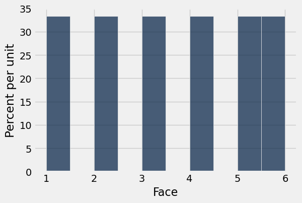

```python
die.hist()
```

```python
roll_bins = np.arange(0.5, 7.5)
roll_bins
```

```
array([ 0.5,  1.5,  2.5,  3.5,  4.5,  5.5,  6.5])
```

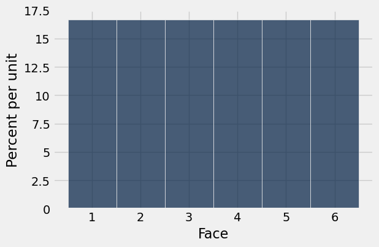

```python
die.hist(bins=roll_bins)
```

Randomly sample using a few different sample sizes and visualize the resulting empirical distributions.

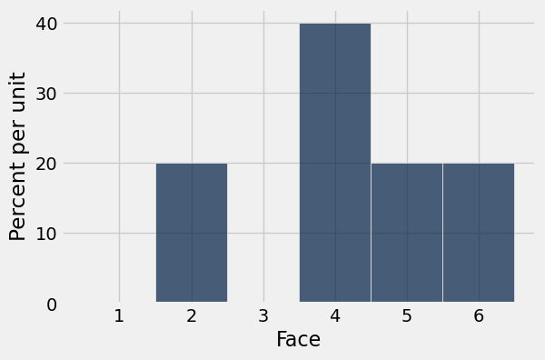

```python
die.sample(10).hist(bins=roll_bins)
```

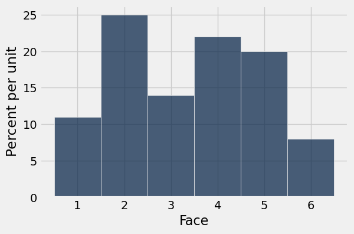

```python
die.sample(100).hist(bins=roll_bins)
```

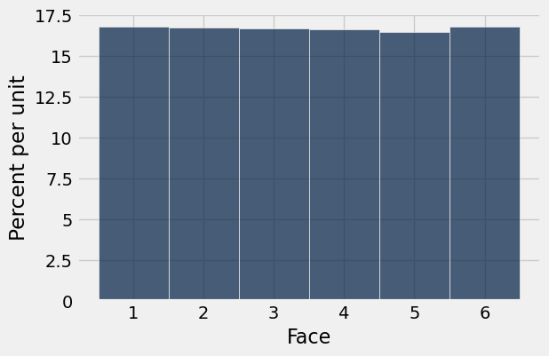

```python
die.sample(100000).hist(bins=roll_bins)
```

```python
...
```

## Law of Large Numbers

### Law of Averages / Law of Large Numbers

- If a chance experiment is repeated many times, independently and under the same conditions, then the proportion of times that an event occurs gets closer to the theoretical probability of the event
- As you increase the number of rolls of a six-sided die, the proportion of times you see the face with five spots gets closer to 1/6

### Empirical Distribution of a Sample

If the sample size is large, then the empirical distribution of a uniform random sample resembles the distribution of the population, with high probability.

### Demo: Large Random Samples

The following code loads the same SFO November 2023 flight delay data in `delays.csv` sourced from the [Bureau of Transportation Statistic's Reporting Carrier On-Time Performance Data](https://www.transtats.bts.gov/DL_SelectFields.aspx?gnoyr_VQ=FGJ&QO_fu146_anzr=b0-gvzr). Additionally, we filter out the rows with missing delay data.

```python
delays = Table.read_table('delays.csv')
sfo_delays = delays.where('ORIGIN', 'SFO').drop(0,2).relabeled('ARR_DELAY', 'DELAY')
nan_filter = np.invert(np.isnan(sfo_delays.column('DELAY')))
sfo_delays = sfo_delays.where(nan_filter)
sfo_delays
```

| OP_CARRIER | DEST | DELAY |
| --- | --- | --- |
| AA | CLT | -23 |
| AA | CLT | -22 |
| AA | CLT | -19 |
| AA | CLT | -17 |
| AA | CLT | -12 |
| AA | DFW | -32 |
| AA | DFW | -25 |
| AA | DFW | -25 |
| AA | DFW | -18 |
| AA | DFW | -17 |

... (11139 rows omitted)

Visualize the empirical distribution of flight delays in the delay data. You'll need to adjust the bins. Take note of the average and median flight delays.

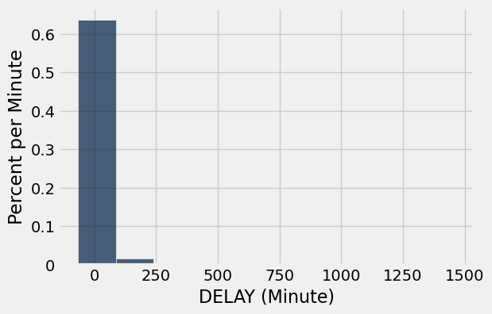

```python
sfo_delays.hist('DELAY', unit='Minute')
```

```python
min_delay = min(sfo_delays.column('DELAY'))
min_delay
```

```
-66.0
```

```python
max_delay = max(sfo_delays.column('DELAY'))
max_delay
```

```
1461.0
```

```python
# The percentile function will be introduced later in the course
percentile_99 = percentile(99, sfo_delays.column('DELAY'))
print(f'99% of the delays are most {percentile_99} mins.')
```

```
99% of the delays are most 151.0 mins.
```

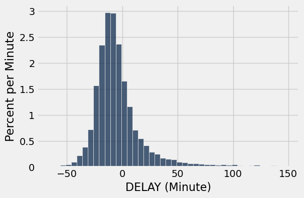

```python
bins = np.arange(min_delay, percentile_99, 5)
sfo_delays.hist('DELAY', bins = bins, unit='Minute')
```

```python
average_delay = np.average(sfo_delays.column('DELAY'))
average_delay
```

```
-0.69082428917391692
```

```python
median_delay = np.median(sfo_delays.column('DELAY'))
median_delay
```

```
-9.0
```

Randomly sample 10 and 1000 flights from the delay data and visualize the distributions of the samples.

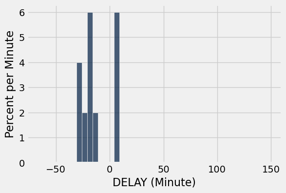

```python
sfo_delays.sample(10).hist('DELAY', bins = bins, unit='Minute')
```

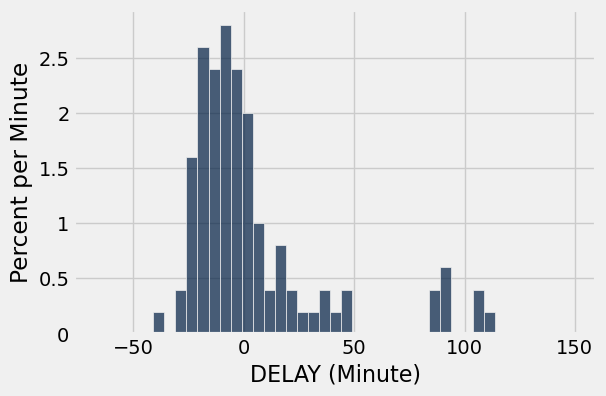

```python
sfo_delays.sample(100).hist('DELAY', bins = bins, unit='Minute')
```

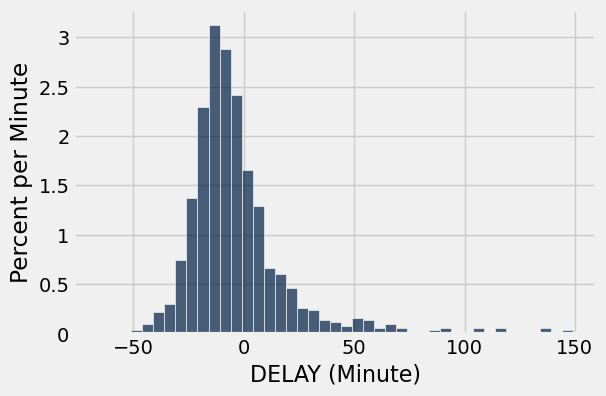

```python
sfo_delays.sample(1000).hist('DELAY', bins = bins, unit='Minute')
```

## A Statistic

### Inference

- Statistical Inference: Making conclusions based on data in random samples
- Example: Use the data to guess the value of an unknown and fixed number by creating an estimate of the unknown quantity that depends on the random sample.

### Terminology

- Parameter: A number associated with the population
- Statistic: A number calculated from the sample
- A statistic can be used as an estimate of a parameter

### Demo: Simulating Statistics

Recall the median for the flight delays (parameter) and compare it to the median statistic associated with a random sample of 10 flights.

```python
median_delay
```

```
-9.0
```

```python
np.median(sfo_delays.sample(10).column('DELAY'))
```

```
-14.5
```

```python
np.median(sfo_delays.sample(10).column('DELAY'))
```

```
-4.0
```

Define a function that randomly samples delay data for an inputted sample size and returns the median delay for that sample.

```python
def sample_median(size):
    return np.median(sfo_delays.sample(size).column('DELAY'))
```

```python
sample_median(10)
```

```
-8.0
```

```python
sample_median(10)
```

```
0.5
```

```python
sample_medians = make_array()
reps = 1_000
sample_size = 2

for _ in np.arange(reps):
    new_median = sample_median(sample_size)
    sample_medians = np.append(sample_medians, new_median)
```

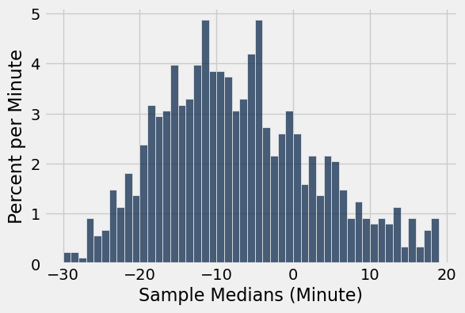

```python
Table().with_column('Sample Medians', sample_medians).hist(bins = np.arange(-30,20), unit='Minute')
```

```python
sample_medians = make_array()
reps = 1_000
sample_size = 10

for _ in np.arange(reps):
    new_median = sample_median(sample_size)
    sample_medians = np.append(sample_medians, new_median)
```

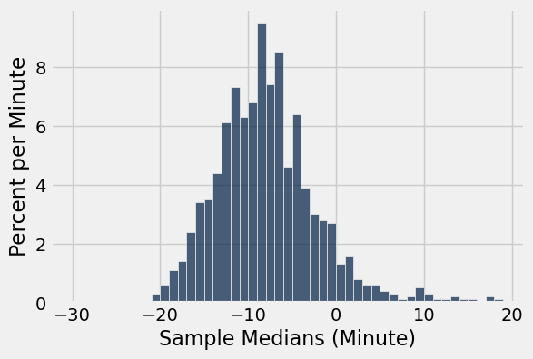

```python
Table().with_column('Sample Medians', sample_medians).hist(bins = np.arange(-30,20), unit='Minute')
```

Repeat the sample simulation except use a sample size of 1000, instead of 10.

```python
sample_medians = make_array()
reps = 1_000
sample_size = 1000

for _ in np.arange(reps):
    new_median = sample_median(sample_size)
    sample_medians = np.append(sample_medians, new_median)
```

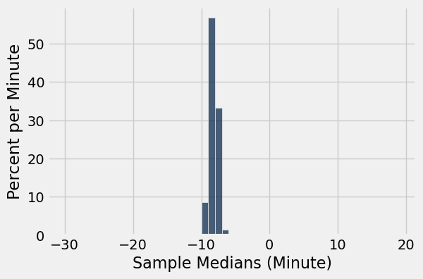

```python
Table().with_column('Sample Medians', sample_medians).hist(bins = np.arange(-30,20), unit='Minute')
```

### Probability Distribution of a Statistic

- Values of a statistic vary because random samples vary
- Sampling distribution (or probability distribution) of the statistic:
  - All possible values of the statistic,
  - and all the corresponding probabilities
  - Can be hard to calculate
    - Either have to do the math
    - Or have to generate all possible samples and calculate the statistic based on each sample

### Empirical Distribution of a Statistic

- Empirical distribution of the statistic:
  - Based on simulated values of the statistic
  - Consists of all the observed values of the statistic,
  - and the proportion of times each value appeared
- Good approximation to the probability distribution of the statistic if the number of repetitions in the simulation is large

## Attribution

This content is licensed under the Creative Commons Attribution-NonCommercial-ShareAlike 4.0 International License (CC BY-NC-SA 4.0) and derived from the Data 8: The Foundations of Data Science offered by the University of California, Berkeley.